# Reproducible Research: Peer Assessment 1

## Loading and preprocessing the data

```r
options(scipen = 1, digits = 2)
```

This first line simply insures that any numbers that may be printed using scientific notation are printed in standard form instead.

```r
require(knitr)
```

```r
require(ggplot2)
require(dplyr)
```

Here we have all packages that are required for the analysis.

```r
if(!file.exists("activity.csv")) {
        unzip("activity.zip")
}
activity <- read.csv("activity.csv")
```

Now we begin to actually load the data. We check to see if the file has already been unzipped, and if it has not, we unzip the file. Then the file is read into the `activity` variable using `read.csv()`.

```r
activity$date <- as.Date(activity$date, "%Y-%m-%d")
```

Lastly, since it will be important in order to answer future questions, we reformat the `date` column of the `activity` data frame to be in the date format.

## What is mean total number of steps taken per day?

```r
aggSteps <- tapply(activity$steps,activity$date,sum,na.rm=TRUE)
```

First, we can use `tapply()` to sum up the number of steps in each day, removing any `NA`’s for now.

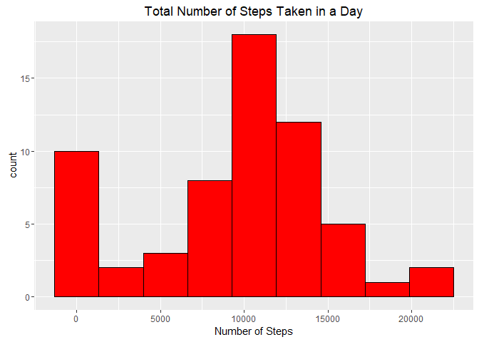

```r
qplot(aggSteps, bins = 9, xlab = "Number of Steps",
      main = "Total Number of Steps Taken in a Day", col = I("black"),
      fill = I("red"))
```

When given only one variable, `qplot()` creates a histogram. 9 bins were chosen in order to give a clear overall picture of the data. Here we see quite a few days in the lowest bin, likely due to days with many or all `NA`’s.

```r
meanSteps <- mean(aggSteps)
medianSteps <-median(aggSteps)
```

The mean number of steps taken per day is 9354.23 and the median number of steps taken per day is 10395.

## What is the average daily activity pattern?

```r
intSteps <- tapply(activity$steps,activity$interval,mean,na.rm=TRUE)
```

Here, `tapply()` is used again, but this time to average the number of steps and this time based on the interval instead of the day (again removing `NA`’s).

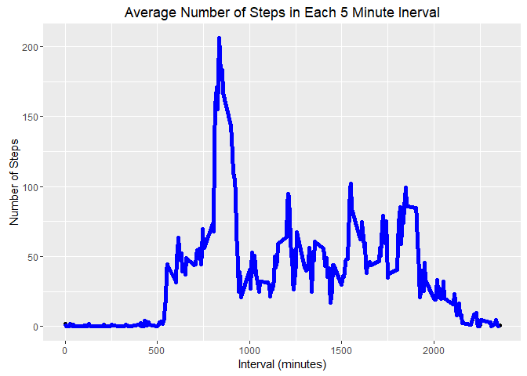

```r
qplot(as.numeric(names(intSteps)),intSteps,
     xlab = "Interval (minutes)", ylab = "Number of Steps",
     main = "Average Number of Steps in Each 5 Minute Inerval") +
        geom_line(col = "blue", size = 2)
```

`tapply()` gives an array where we have a vector of averages, and each element is given its respective interval as a name. Thus the names of `intSteps` are used as the independent variable and the calculated means are used as the dependent variable to create this time series graph.

```r
maxSteps <- max(intSteps)
maxInt <- names(intSteps[which(intSteps == maxSteps)])
```

The interval with the most average steps is 835 during which an average of 206.17 steps are taken.

## Imputing missing values

```r
colSums(is.na(activity))
```

```
##    steps     date interval
##     2304        0        0
```

```r
countNA <- sum(is.na(activity$steps))
```

There are 2304 observations that have an `NA` value listed. We see that the `steps` column is the only one that has any `NA` values at all.

```r
modAct <- activity$steps
modAct[c(1,17568)] <- intSteps[c(1,288)]
for (i in 2:17567){
        if (is.na(modAct[i])){
                near <- mean(c(activity$steps[i-1], activity$steps[i+1]))
                if (is.na(near))
                        modAct[i] <- intSteps[which(activity$interval[i] == names(intSteps))]
                else
                        modAct[i] <- mean(c(near, intSteps[which(activity$interval[i] == names(intSteps))]))
        }
}
newAct <- activity
newAct$steps <- modAct
```

```r
newAggSteps <- tapply(newAct$steps,newAct$date,sum,na.rm=TRUE)
```

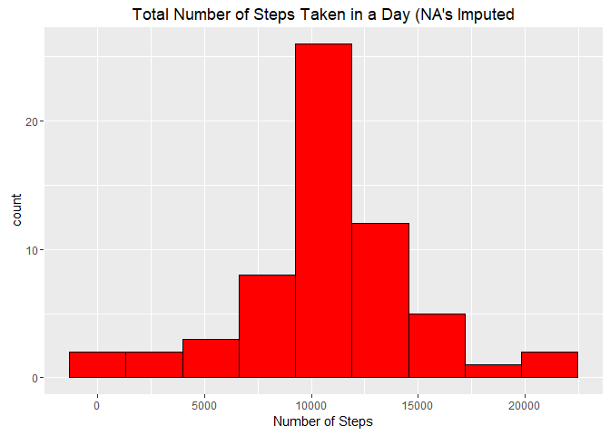

```r
qplot(newAggSteps, bins = 9, xlab = "Number of Steps",
      main = "Total Number of Steps Taken in a Day (NA's Imputed",
      col = I("black"), fill = I("red"))
```

These two steps are equivalent to those taken before, just with all of the `NA` values having been imputed. Here we see fewer values in the lowest bin since the days that were mostly or all `NA` have now been replaced by actual values. This gives the distribution a more normal shape.

```r
meanNewSteps <- mean(newAggSteps)
medianNewSteps <-median(newAggSteps)
```

The mean number of steps taken per day is 10766.19 and the median number of steps taken per day is 10766.19. It is clear that both the mean and the median number of steps has increased when replacing the `NA` values. Obviously adding in more values will only increase the estimates of total daily number of steps.

## Are there differences in activity patterns between weekdays and weekends?

```r
newAct <- mutate(newAct,
                 type = as.factor(ifelse(weekdays(date) %in% c("Saturday","Sunday"), "weekend", "weekday")))
```

First, a new factor variable is created that checks which day of the week the observation ocurred during and assigns the new variable a level of either `"weekend"` or `"weekday"`.

```r
weekdayAct <- filter(newAct, type == "weekday")
weekendAct <- filter(newAct, type == "weekend")
weekdayInt <- tapply(weekdayAct$steps, weekdayAct$interval, mean)
weekendInt <- tapply(weekendAct$steps, weekendAct$interval, mean)
```

First, the `newAct` data frame is filtered into two new data frames based on type of day (weekday/weekend). Then, just as before, the number of steps are averaged by interval.

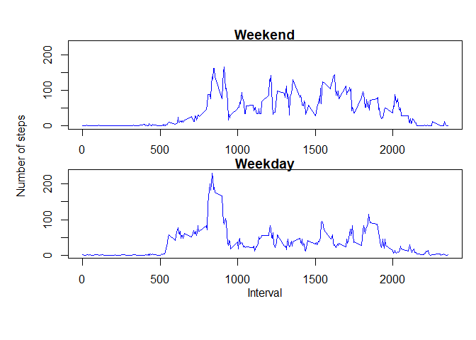

```r
par(mfrow = c(2,1), mar = c(2,1,1,1), oma = c(4,4,2,0))
rng <- range(c(weekendInt,weekdayInt))
plot(as.numeric(names(weekendInt)), weekendInt, xlab = "", ylab = "",
     main = "Weekend", type = "l", col = "blue", ylim = rng)
plot(as.numeric(names(weekdayInt)), weekdayInt, xlab = "", ylab = "",
     main = "Weekday", type = "l", col = "blue", ylim = rng)
mtext("Interval", side = 1, outer = TRUE, line = 0)
mtext("Number of steps",side = 2, outer = TRUE, line = 2)
```

The data is then plotted as a time series as before, using the `rng` variable to insure that each plot has the same `ylim` argument. This allows for an easier comparison between the two plots.